# Capstone Project for DTSC 691

## The top two most important features when determining food desert status are: median family income and poverty rate.

Three features were found to be of zero importance to this AdaBoost model: percentage of white people in the census tract, percentage of asian people, and percentage of people who only graduated high school. When visualizing the data, we saw that percentage of white people in a tract was negatively correlated with food desert status, but not by a very high number (-0.11)

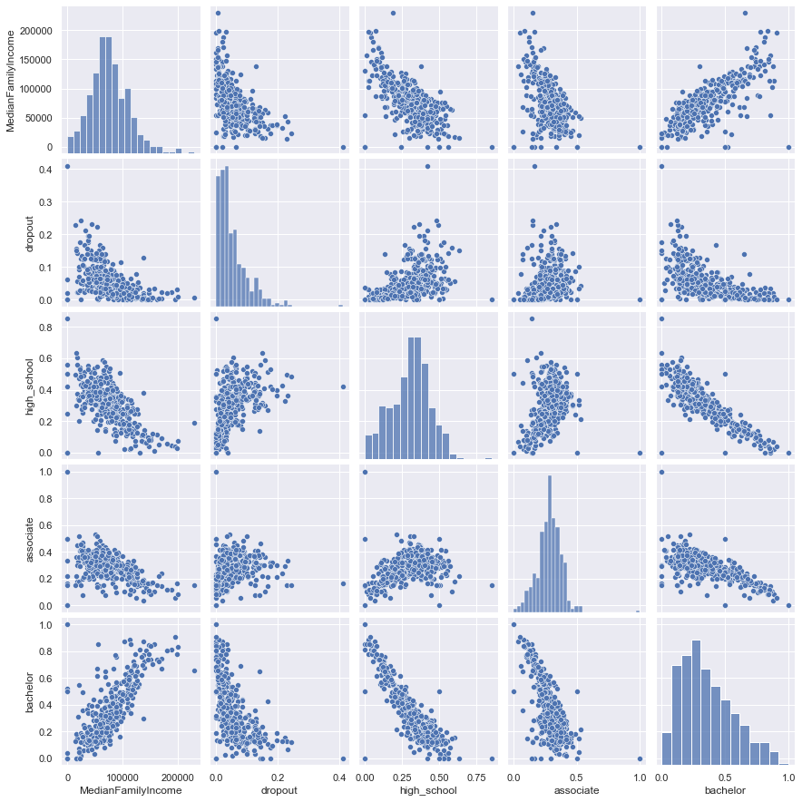

```python
sns.set_theme(style='darkgrid')

# separating data into median family income and educational attainment
incomed = alldata[['MedianFamilyIncome','dropout','high_school','associate','bachelor']]
sns.pairplot(incomed)

plt.show()
```

## There seems to be a higher percentage of individuals with a Bachelors degree who also have a higher than average income.

From the bottom left plot we can see that as the amount of individuals with a Bachelor's degree goes up, the median family income also goes up.

# In Conclusion,